# CS 422 Section 04 Homework 1

Thomas Ehling A20432671

## 2 Problems

```r
library(ggplot2)
library(dplyr)
library(corrplot)
library(psych)
```

## 2.1 Problem 1

### (a) Reading the college dataset

```r
setwd('/home/french_magician/Documents/Chicago/DM/Assigment_1')
df_college <- read.csv("College.csv", sep=",", header=T)
head(df_college,6)
```

|  | Name | Private | Apps | Accept | Enroll | Top10perc | Top25perc | F.Undergrad | P.Undergrad | Outstate | Room.Board | Books | Personal | PhD | Terminal | S.F.Ratio | perc.alumni | Expend | Grad.Rate |
| --- | --- | --- | --- | --- | --- | --- | --- | --- | --- | --- | --- | --- | --- | --- | --- | --- | --- | --- | --- |
| 1 | Abilene Christian University | Yes | 1660 | 1232 | 721 | 23 | 52 | 2885 | 537 | 7440 | 3300 | 450 | 2200 | 70 | 78 | 18.1 | 12 | 7041 | 60 |
| 2 | Adelphi University | Yes | 2186 | 1924 | 512 | 16 | 29 | 2683 | 1227 | 12280 | 6450 | 750 | 1500 | 29 | 30 | 12.2 | 16 | 10527 | 56 |
| 3 | Adrian College | Yes | 1428 | 1097 | 336 | 22 | 50 | 1036 | 99 | 11250 | 3750 | 400 | 1165 | 53 | 66 | 12.9 | 30 | 8735 | 54 |
| 4 | Agnes Scott College | Yes | 417 | 349 | 137 | 60 | 89 | 510 | 63 | 12960 | 5450 | 450 | 875 | 92 | 97 | 7.7 | 37 | 19016 | 59 |
| 5 | Alaska Pacific University | Yes | 193 | 146 | 55 | 16 | 44 | 249 | 869 | 7560 | 4120 | 800 | 1500 | 76 | 72 | 11.9 | 2 | 10922 | 15 |
| 6 | Albertson College | Yes | 587 | 479 | 158 | 38 | 62 | 678 | 41 | 13500 | 3335 | 500 | 675 | 67 | 73 | 9.4 | 11 | 9727 | 55 |

### (b) Number of private and public colleges

```r
cat("There are", sum(df_college$Private == 'Yes'),"private colleges")
```

```
There are 565 private colleges
```

Number of public colleges :

```r
cat("There are", sum(df_college$Private == 'No'),"private colleges")
```

```
There are 212 private colleges
```

### (c) We create 2 dataframes, one for the public colleges and one for the privates, and print their histogram :

```r
df_privates <- dplyr::filter(df_college, Private == "Yes")
head(df_privates)
```

|  | Name | Private | Apps | Accept | Enroll | Top10perc | Top25perc | F.Undergrad | P.Undergrad | Outstate | Room.Board | Books | Personal | PhD | Terminal | S.F.Ratio | perc.alumni | Expend | Grad.Rate |
| --- | --- | --- | --- | --- | --- | --- | --- | --- | --- | --- | --- | --- | --- | --- | --- | --- | --- | --- | --- |
| 1 | Abilene Christian University | Yes | 1660 | 1232 | 721 | 23 | 52 | 2885 | 537 | 7440 | 3300 | 450 | 2200 | 70 | 78 | 18.1 | 12 | 7041 | 60 |
| 2 | Adelphi University | Yes | 2186 | 1924 | 512 | 16 | 29 | 2683 | 1227 | 12280 | 6450 | 750 | 1500 | 29 | 30 | 12.2 | 16 | 10527 | 56 |
| 3 | Adrian College | Yes | 1428 | 1097 | 336 | 22 | 50 | 1036 | 99 | 11250 | 3750 | 400 | 1165 | 53 | 66 | 12.9 | 30 | 8735 | 54 |
| 4 | Agnes Scott College | Yes | 417 | 349 | 137 | 60 | 89 | 510 | 63 | 12960 | 5450 | 450 | 875 | 92 | 97 | 7.7 | 37 | 19016 | 59 |
| 5 | Alaska Pacific University | Yes | 193 | 146 | 55 | 16 | 44 | 249 | 869 | 7560 | 4120 | 800 | 1500 | 76 | 72 | 11.9 | 2 | 10922 | 15 |
| 6 | Albertson College | Yes | 587 | 479 | 158 | 38 | 62 | 678 | 41 | 13500 | 3335 | 500 | 675 | 67 | 73 | 9.4 | 11 | 9727 | 55 |

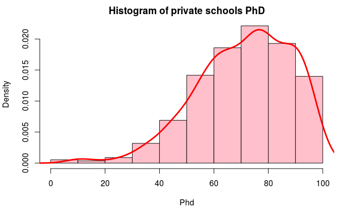

```r
hist(df_privates$PhD, freq = FALSE,  xlab="Phd", main = "Histogram of private schools PhD", col = "pink")
lines(density(df_privates$PhD), lwd = 3, col = "red")
```

```r
df_publics <- dplyr::filter(df_college, Private == "No")
head(df_publics)
```

|  | Name | Private | Apps | Accept | Enroll | Top10perc | Top25perc | F.Undergrad | P.Undergrad | Outstate | Room.Board | Books | Personal | PhD | Terminal | S.F.Ratio | perc.alumni | Expend | Grad.Rate |
| --- | --- | --- | --- | --- | --- | --- | --- | --- | --- | --- | --- | --- | --- | --- | --- | --- | --- | --- | --- |
| 1 | Angelo State University | No | 3540 | 2001 | 1016 | 24 | 54 | 4190 | 1512 | 5130 | 3592 | 500 | 2000 | 60 | 62 | 23.1 | 5 | 4010 | 34 |
| 2 | Appalachian State University | No | 7313 | 4664 | 1910 | 20 | 63 | 9940 | 1035 | 6806 | 2540 | 96 | 2000 | 83 | 96 | 18.3 | 14 | 5854 | 70 |
| 3 | Arizona State University Main campus | No | 12809 | 10308 | 3761 | 24 | 49 | 22593 | 7585 | 7434 | 4850 | 700 | 2100 | 88 | 93 | 18.9 | 5 | 4602 | 48 |
| 4 | Arkansas Tech University | No | 1734 | 1729 | 951 | 12 | 52 | 3602 | 939 | 3460 | 2650 | 450 | 1000 | 57 | 60 | 19.6 | 5 | 4739 | 48 |
| 5 | Auburn University-Main Campus | No | 7548 | 6791 | 3070 | 25 | 57 | 16262 | 1716 | 6300 | 3933 | 600 | 1908 | 85 | 91 | 16.7 | 18 | 6642 | 69 |
| 6 | Bemidji State University | No | 1208 | 877 | 546 | 12 | 36 | 3796 | 824 | 4425 | 2700 | 660 | 1800 | 57 | 62 | 19.6 | 16 | 3752 | 46 |

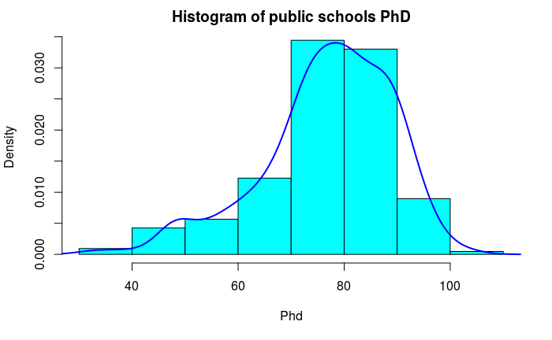

```r
hist(df_publics$PhD, freq = FALSE, xlab="Phd", main = "Histogram of public schools PhD", col = "cyan")
lines(density(df_publics$PhD), lwd = 2,  col = "blue")
```

```r
hist(df_publics$PhD, col="cyan", freq=FALSE, main = "Histogram of PhDs",xlab = "PhDs")
hist(df_privates$PhD, freq=FALSE, col="pink" , add=TRUE)
```

```r
hist(df_publics$PhD, col="cyan", freq=FALSE, add=TRUE)
hist(df_privates$PhD, freq=FALSE, col=rgb(1,0,1,0.5) , add=TRUE)
```

```r
lines(density(df_publics$PhD), lwd = 2,  col = "blue")
lines(density(df_privates$PhD), lwd = 3, col = "red")
```

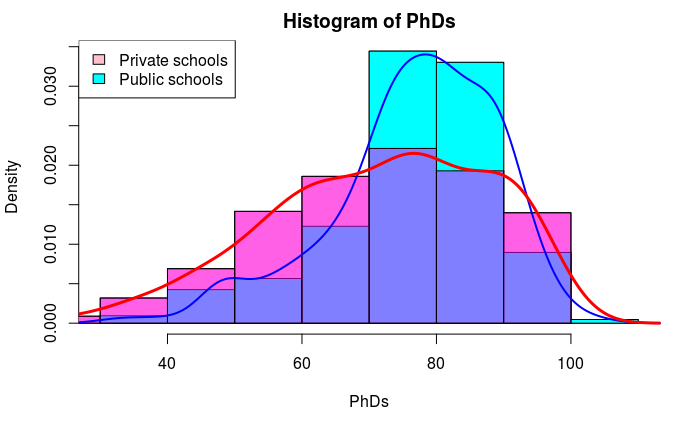

```r
legend("topleft", c("Private schools", "Public schools"), fill=c("pink", "cyan"))
```

We can conclude from the histograms that public schools are top-heavy with respect to PhD faculty.

### (d) Print of the Five first and last colleges according to their grades

```r
df_grad <- df_college
df_grad <- dplyr::select(df_grad, Name, Grad.Rate)
df_grad <- dplyr::arrange(df_grad, df_grad$Grad.Rate)
```

The Top Five college with the highest graduation rate are:

```r
tail(df_grad, 5)
```

|  | Name | Grad.Rate |
| --- | --- | --- |
| 773 | Missouri Southern State College | 100 |
| 774 | Santa Clara University | 100 |
| 775 | Siena College | 100 |
| 776 | University of Richmond | 100 |
| 777 | Cazenovia College | 118 |

The Top Five college with the lowest graduation rate are:

```r
head(df_grad, 5)
```

|  | Name | Grad.Rate |
| --- | --- | --- |
| 1 | Texas Southern University | 10 |
| 2 | Alaska Pacific University | 15 |
| 3 | Montreat-Anderson College | 15 |
| 4 | Brewton-Parker College | 18 |
| 5 | Claflin College | 21 |

### (e).i. summarry of the data_set

```r
summary(df_college)
```

```
                           Name     Private        Apps           Accept          Enroll
 Abilene Christian University:  1   No :212   Min.   :   81   Min.   :   72   Min.   :  35
 Adelphi University          :  1   Yes:565   1st Qu.:  776   1st Qu.:  604   1st Qu.: 242
 Adrian College              :  1             Median : 1558   Median : 1110   Median : 434
 Agnes Scott College         :  1             Mean   : 3002   Mean   : 2019   Mean   : 780
 Alaska Pacific University   :  1             3rd Qu.: 3624   3rd Qu.: 2424   3rd Qu.: 902
 Albertson College           :  1             Max.   :48094   Max.   :26330   Max.   :6392
 (Other)                     :771
   Top10perc       Top25perc      F.Undergrad     P.Undergrad         Outstate       Room.Board
 Min.   : 1.00   Min.   :  9.0   Min.   :  139   Min.   :    1.0   Min.   : 2340   Min.   :1780
 1st Qu.:15.00   1st Qu.: 41.0   1st Qu.:  992   1st Qu.:   95.0   1st Qu.: 7320   1st Qu.:3597
 Median :23.00   Median : 54.0   Median : 1707   Median :  353.0   Median : 9990   Median :4200
 Mean   :27.56   Mean   : 55.8   Mean   : 3700   Mean   :  855.3   Mean   :10441   Mean   :4358
 3rd Qu.:35.00   3rd Qu.: 69.0   3rd Qu.: 4005   3rd Qu.:  967.0   3rd Qu.:12925   3rd Qu.:5050
 Max.   :96.00   Max.   :100.0   Max.   :31643   Max.   :21836.0   Max.   :21700   Max.   :8124

     Books           Personal         PhD            Terminal       S.F.Ratio      perc.alumni
 Min.   :  96.0   Min.   : 250   Min.   :  8.00   Min.   : 24.0   Min.   : 2.50   Min.   : 0.00
 1st Qu.: 470.0   1st Qu.: 850   1st Qu.: 62.00   1st Qu.: 71.0   1st Qu.:11.50   1st Qu.:13.00
 Median : 500.0   Median :1200   Median : 75.00   Median : 82.0   Median :13.60   Median :21.00
 Mean   : 549.4   Mean   :1341   Mean   : 72.66   Mean   : 79.7   Mean   :14.09   Mean   :22.74
 3rd Qu.: 600.0   3rd Qu.:1700   3rd Qu.: 85.00   3rd Qu.: 92.0   3rd Qu.:16.50   3rd Qu.:31.00
 Max.   :2340.0   Max.   :6800   Max.   :103.00   Max.   :100.0   Max.   :39.80   Max.   :64.00

     Expend        Grad.Rate
 Min.   : 3186   Min.   : 10.00
 1st Qu.: 6751   1st Qu.: 53.00
 Median : 8377   Median : 65.00
 Mean   : 9660   Mean   : 65.46
 3rd Qu.:10830   3rd Qu.: 78.00
 Max.   :56233   Max.   :118.00
```

### (e).ii. scatterplot

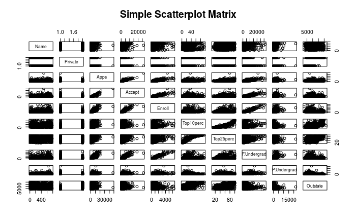

```r
pairs(df_college[,1:10], main="Simple Scatterplot Matrix")
```

### (e).iii. boxplots of donations

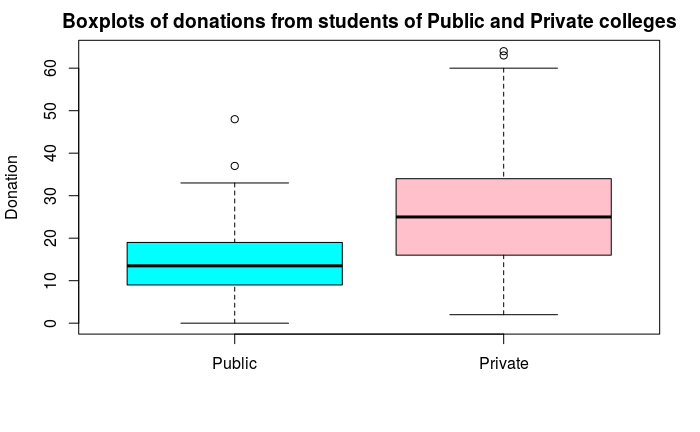

```r
boxplot(df_publics$perc.alumni, df_privates$perc.alumni,names=c("Public", "Private"), ylab = "Donation", main = "Boxplots of donations from students of Public and Private colleges", col = c("cyan", "pink") )
```

We can conclude that the students from the private colleges donate more money to their colleges that the students from the public ones.

### (e).iv. boxplots of PhD

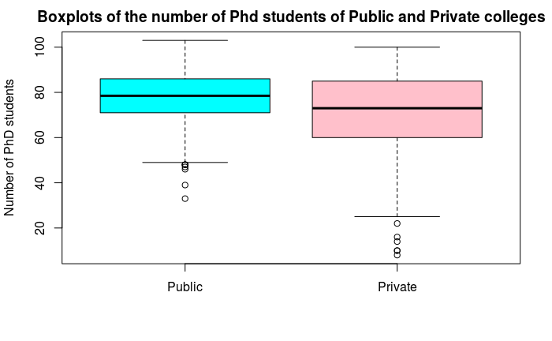

```r
boxplot(df_publics$PhD, df_privates$PhD,names=c("Public", "Private"), ylab = "Number of PhD students", main = "Boxplots of the number of Phd students of Public and Private colleges", col = c("cyan", "pink"))
```

We can conclude that there are more students from the public colleges who are Phd students, compare to private colleges.

### (e).v. New qualitative variable

```r
col_elites <- rep("No", nrow(df_college))
col_elites[df_college$Top10perc > 50] <- "Yes"
col_elites <- as.factor(col_elites)
df_college <- data.frame(df_college, col_elites)
names(df_college)[ncol(df_college)] <- "Elite"
summary(df_college)
```

```
                           Name     Private        Apps           Accept          Enroll
 Abilene Christian University:  1   No :212   Min.   :   81   Min.   :   72   Min.   :  35
 Adelphi University          :  1   Yes:565   1st Qu.:  776   1st Qu.:  604   1st Qu.: 242
 Adrian College              :  1             Median : 1558   Median : 1110   Median : 434
 Agnes Scott College         :  1             Mean   : 3002   Mean   : 2019   Mean   : 780
 Alaska Pacific University   :  1             3rd Qu.: 3624   3rd Qu.: 2424   3rd Qu.: 902
 Albertson College           :  1             Max.   :48094   Max.   :26330   Max.   :6392
 (Other)                     :771
   Top10perc       Top25perc      F.Undergrad     P.Undergrad         Outstate       Room.Board
 Min.   : 1.00   Min.   :  9.0   Min.   :  139   Min.   :    1.0   Min.   : 2340   Min.   :1780
 1st Qu.:15.00   1st Qu.: 41.0   1st Qu.:  992   1st Qu.:   95.0   1st Qu.: 7320   1st Qu.:3597
 Median :23.00   Median : 54.0   Median : 1707   Median :  353.0   Median : 9990   Median :4200
 Mean   :27.56   Mean   : 55.8   Mean   : 3700   Mean   :  855.3   Mean   :10441   Mean   :4358
 3rd Qu.:35.00   3rd Qu.: 69.0   3rd Qu.: 4005   3rd Qu.:  967.0   3rd Qu.:12925   3rd Qu.:5050
 Max.   :96.00   Max.   :100.0   Max.   :31643   Max.   :21836.0   Max.   :21700   Max.   :8124

     Books           Personal         PhD            Terminal       S.F.Ratio      perc.alumni
 Min.   :  96.0   Min.   : 250   Min.   :  8.00   Min.   : 24.0   Min.   : 2.50   Min.   : 0.00
 1st Qu.: 470.0   1st Qu.: 850   1st Qu.: 62.00   1st Qu.: 71.0   1st Qu.:11.50   1st Qu.:13.00
 Median : 500.0   Median :1200   Median : 75.00   Median : 82.0   Median :13.60   Median :21.00
 Mean   : 549.4   Mean   :1341   Mean   : 72.66   Mean   : 79.7   Mean   :14.09   Mean   :22.74
 3rd Qu.: 600.0   3rd Qu.:1700   3rd Qu.: 85.00   3rd Qu.: 92.0   3rd Qu.:16.50   3rd Qu.:31.00
 Max.   :2340.0   Max.   :6800   Max.   :103.00   Max.   :100.0   Max.   :39.80   Max.   :64.00

     Expend        Grad.Rate      Elite
 Min.   : 3186   Min.   : 10.00   No :699
 1st Qu.: 6751   1st Qu.: 53.00   Yes: 78
 Median : 8377   Median : 65.00
 Mean   : 9660   Mean   : 65.46
 3rd Qu.:10830   3rd Qu.: 78.00
 Max.   :56233   Max.   :118.00
```

After creating and addind the new qualitative variable “Elites” as a new column of the college dataframe, we can note they are only 78 Elites colleges.

6. Histograms

```r
par(mfrow=c(2,3))
hist(df_college$Apps, main="Apps", col = "chartreuse2")
hist(df_college$Accept, main="Accepts", col = "chocolate2")
```

```r
hist(df_college$Enroll, main="Enroll", col = "cyan")
hist(df_college$Room.Board, main="Room board", col = "lightblue3")
```

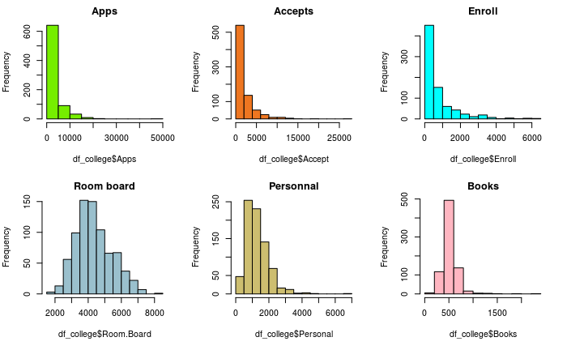

```r
hist(df_college$Personal, main="Personnal", col="lightgoldenrod3")
hist(df_college$Books, main="Books", col="lightpink")
```

```r
layout(matrix(c(1,1,2,3), 2, 2, byrow = TRUE))
hist(df_college$F.Undergrad, main="Full time Undergraduate", col = "mediumspringgreen")
hist(df_college$Top10perc, main="Top of the school", col = "green")
```

```r
hist(df_college$Top25perc, add=T, col = "red")
hist(df_college$Top10perc, col = "green", add=T)
```

```r
hist(df_college$Top25perc, add=T, col = rgb(1,0,1,0.5))
legend("topright", c("Top 10%", "Top 25%"), fill=c("green", "red"))
```

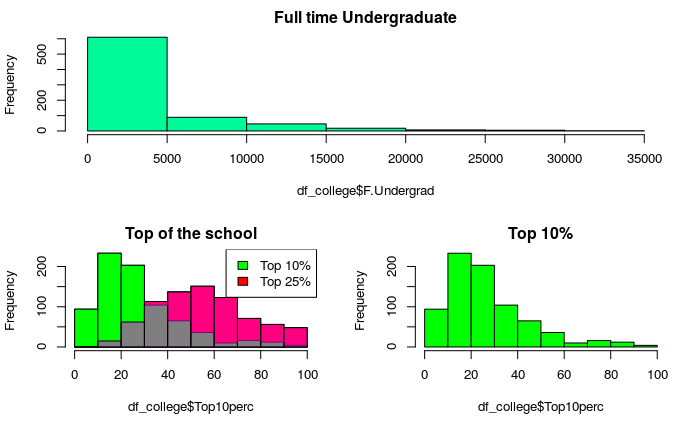

```r
hist(df_college$Top10perc, main="Top 10%", col = "green")
```

### vii. Exploration

Here an example of what I would do to better understand the data set. After looking at the scatterplot matrix I would use the ggplot2 library to look at the scatterplot of the most related variables, displaying the linear regression line.

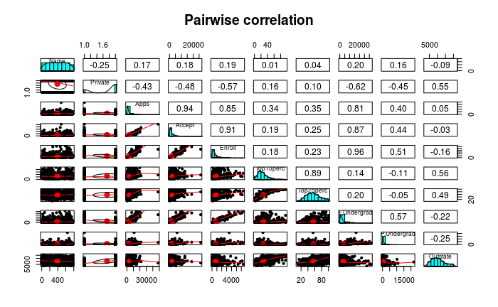

```r
pairs.panels(df_college[,1:10], main="Pairwise correlation")
```

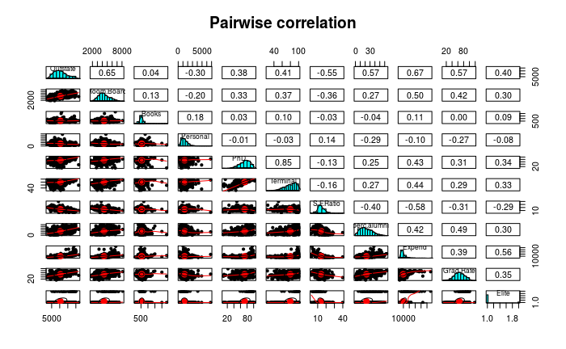

```r
pairs.panels(df_college[,10:20], main="Pairwise correlation")
```

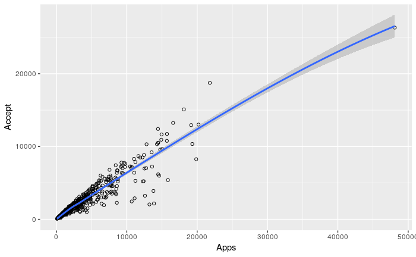

```r
ggplot(df_college, aes(x=Apps, y=Accept)) +
    geom_point(shape=1) +    # Use hollow circles
    geom_smooth()            # Add a loess smoothed fit curve with confidence region
```

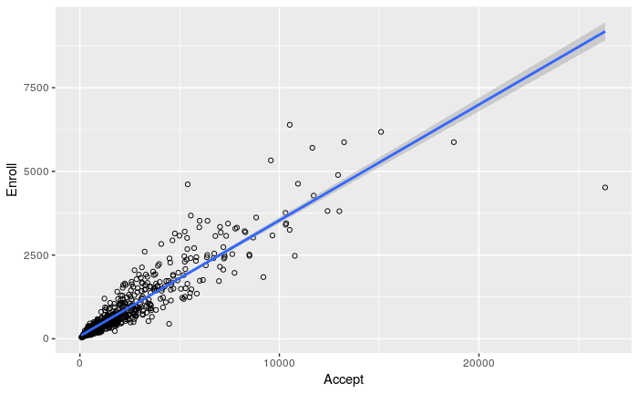

```r
ggplot(df_college, aes(x=Accept, y=Enroll)) +
    geom_point(shape=1) +    # Use hollow circles
    geom_smooth(method=lm)   # Add linear regression line
```

```r
                             #  (by default includes 95% confidence region)
```

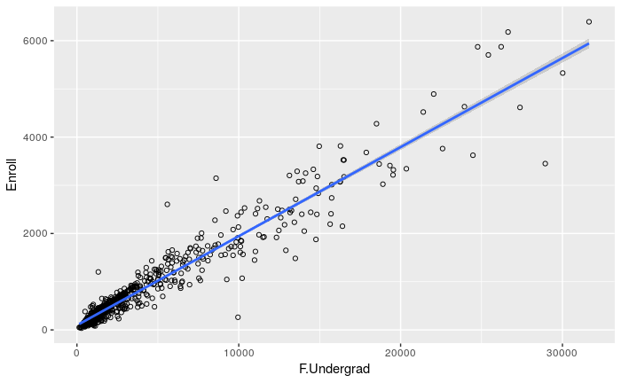

```r
ggplot(df_college, aes(x=F.Undergrad, y=Enroll)) +
    geom_point(shape=1) +    # Use hollow circles
    geom_smooth(method=lm)   # Add linear regression line
```

```r
                             #  (by default includes 95% confidence region)
```

For the few models plotted here, a linear regression model would seems to be pertinent.

## 2.2 Problem 2

```r
df_mpg <- read.csv("auto-mpg.csv", sep=",", header=T)
df_mpg
```

| mpg | cylinders | displacement | horsepower | weight | acceleration | model.year | origin | car.name |
| --- | --- | --- | --- | --- | --- | --- | --- | --- |
| 18.0 | 8 | 307.0 | 130 | 3504 | 12.0 | 70 | 1 | chevrolet chevelle malibu |
| 15.0 | 8 | 350.0 | 165 | 3693 | 11.5 | 70 | 1 | buick skylark 320 |
| 18.0 | 8 | 318.0 | 150 | 3436 | 11.0 | 70 | 1 | plymouth satellite |
| 16.0 | 8 | 304.0 | 150 | 3433 | 12.0 | 70 | 1 | amc rebel sst |
| 17.0 | 8 | 302.0 | 140 | 3449 | 10.5 | 70 | 1 | ford torino |
| 15.0 | 8 | 429.0 | 198 | 4341 | 10.0 | 70 | 1 | ford galaxie 500 |
| 14.0 | 8 | 454.0 | 220 | 4354 | 9.0 | 70 | 1 | chevrolet impala |
| 14.0 | 8 | 440.0 | 215 | 4312 | 8.5 | 70 | 1 | plymouth fury iii |
| 14.0 | 8 | 455.0 | 225 | 4425 | 10.0 | 70 | 1 | pontiac catalina |
| 15.0 | 8 | 390.0 | 190 | 3850 | 8.5 | 70 | 1 | amc ambassador dpl |

[output cut: 388 more lines]

### (a).i

```r
interrogation_rows <- which(df_mpg$horsepower == '?')
cat("There are", length(interrogation_rows), "'?' at the indexes :", interrogation_rows)
```

```
There are 6 '?' at the indexes : 33 127 331 337 355 375
```

```r
df_mpg <- df_mpg[-which(df_mpg$horsepower == '?'), ]
df_mpg
```

|  | mpg | cylinders | displacement | horsepower | weight | acceleration | model.year | origin | car.name |
| --- | --- | --- | --- | --- | --- | --- | --- | --- | --- |
| 1 | 18.0 | 8 | 307.0 | 130 | 3504 | 12.0 | 70 | 1 | chevrolet chevelle malibu |
| 2 | 15.0 | 8 | 350.0 | 165 | 3693 | 11.5 | 70 | 1 | buick skylark 320 |
| 3 | 18.0 | 8 | 318.0 | 150 | 3436 | 11.0 | 70 | 1 | plymouth satellite |
| 4 | 16.0 | 8 | 304.0 | 150 | 3433 | 12.0 | 70 | 1 | amc rebel sst |
| 5 | 17.0 | 8 | 302.0 | 140 | 3449 | 10.5 | 70 | 1 | ford torino |
| 6 | 15.0 | 8 | 429.0 | 198 | 4341 | 10.0 | 70 | 1 | ford galaxie 500 |
| 7 | 14.0 | 8 | 454.0 | 220 | 4354 | 9.0 | 70 | 1 | chevrolet impala |
| 8 | 14.0 | 8 | 440.0 | 215 | 4312 | 8.5 | 70 | 1 | plymouth fury iii |
| 9 | 14.0 | 8 | 455.0 | 225 | 4425 | 10.0 | 70 | 1 | pontiac catalina |
| 10 | 15.0 | 8 | 390.0 | 190 | 3850 | 8.5 | 70 | 1 | amc ambassador dpl |

[output cut: 382 more lines]

We can check that the interrogation dots have been removed because the new data_set only contains 392 rows.

### (a).ii

```r
str(df_mpg$horsepower)
```

```
 Factor w/ 94 levels "?","100","102",..: 17 35 29 29 24 42 47 46 48 40 ...
```

```r
df_mpg$horsepower = as.integer(df_mpg$horsepower)
str(df_mpg)
```

```
'data.frame':   392 obs. of  9 variables:
 $ mpg         : num  18 15 18 16 17 15 14 14 14 15 ...
 $ cylinders   : int  8 8 8 8 8 8 8 8 8 8 ...
 $ displacement: num  307 350 318 304 302 429 454 440 455 390 ...
 $ horsepower  : int  17 35 29 29 24 42 47 46 48 40 ...
 $ weight      : int  3504 3693 3436 3433 3449 4341 4354 4312 4425 3850 ...
 $ acceleration: num  12 11.5 11 12 10.5 10 9 8.5 10 8.5 ...
 $ model.year  : int  70 70 70 70 70 70 70 70 70 70 ...
 $ origin      : int  1 1 1 1 1 1 1 1 1 1 ...
 $ car.name    : Factor w/ 305 levels "amc ambassador brougham",..: 50 37 232 15 162 142 55 224 242 2 ...
```

All attributes are either numeric or integer except for Car.name

### (b)

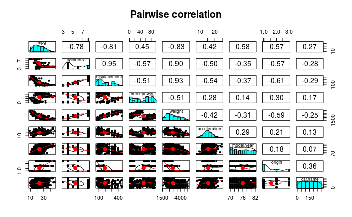

```r
pairs.panels(df_mpg, main="Pairwise correlation")
```

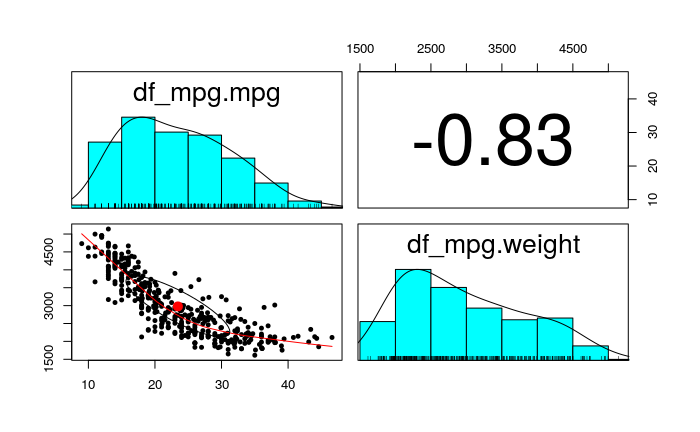

```r
pairs.panels(data.frame(df_mpg$mpg, df_mpg$weight))
```

Wa can notice a strong correlation between mpg and the weight.

```r
model <- lm(mpg ~ weight, data = df_mpg)
summary(model)
```

```
Call:
lm(formula = mpg ~ weight, data = df_mpg)

Residuals:
     Min       1Q   Median       3Q      Max
-11.9736  -2.7556  -0.3358   2.1379  16.5194

Coefficients:
             Estimate Std. Error t value Pr(>|t|)
(Intercept) 46.216524   0.798673   57.87   <2e-16 ***
weight      -0.007647   0.000258  -29.64   <2e-16 ***
---
Signif. codes:  0 ‘***’ 0.001 ‘**’ 0.01 ‘*’ 0.05 ‘.’ 0.1 ‘ ’ 1

Residual standard error: 4.333 on 390 degrees of freedom
Multiple R-squared:  0.6926,    Adjusted R-squared:  0.6918
F-statistic: 878.8 on 1 and 390 DF,  p-value: < 2.2e-16
```

The correlation seems to be very strong indeed, as thep-values associated with the F-statistics are close to zero.

```r
rmse <- sqrt(sum((model$residuals)^2)/nrow(df_mpg))
cat("The RMSE value is",rmse)
```

```
The RMSE value is 4.321645
```

We cannot really assess the value of RSE or RMSE yet, because it depends on the precision needed for the result and the precision of models with other predictors.

### (c)

Plot of the model to check visually for obvious anormalities :

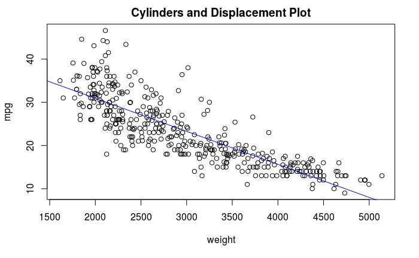

```r
plot(df_mpg$weight, df_mpg$mpg, main= "Cylinders and Displacement Plot", xlab = "weight", ylab = "mpg")
abline(model, col = "blue")
```

The model seems to fit correcly the data. (No obvious anormalities)

### (d).i

Set-up :

```r
set.seed(1122)
index <- sample(1:nrow(df_mpg), 0.80*dim(df_mpg)[1])
df_train <- df_mpg[index, ]
df_test <- df_mpg[-index, ]
```

We shouldn’t use car.names as a predictor because car names are random variables, that we use as indexes, so they can’t produce any relevent result.

### (d).ii

Creation of the linear regression model :

```r
model_all <- lm(mpg ~ .-car.name, data = df_train)
summary(model_all)
```

```
Call:
lm(formula = mpg ~ . - car.name, data = df_train)

Residuals:
    Min      1Q  Median      3Q     Max
-7.9695 -1.9595 -0.0051  1.8549 12.0380

Coefficients:
               Estimate Std. Error t value Pr(>|t|)
(Intercept)  -2.265e+01  4.739e+00  -4.779 2.74e-06 ***
cylinders    -2.277e-01  3.599e-01  -0.633   0.5274
displacement  1.912e-02  7.617e-03   2.511   0.0126 *
horsepower    1.543e-02  7.680e-03   2.009   0.0454 *
weight       -6.947e-03  6.064e-04 -11.457  < 2e-16 ***
acceleration  1.555e-01  8.095e-02   1.921   0.0557 .
model.year    7.740e-01  5.481e-02  14.121  < 2e-16 ***
origin        1.513e+00  2.957e-01   5.115 5.54e-07 ***
---
Signif. codes:  0 ‘***’ 0.001 ‘**’ 0.01 ‘*’ 0.05 ‘.’ 0.1 ‘ ’ 1

Residual standard error: 3.188 on 305 degrees of freedom
Multiple R-squared:  0.8389,    Adjusted R-squared:  0.8352
F-statistic: 226.8 on 7 and 305 DF,  p-value: < 2.2e-16
```

```r
# Mean squared error
mse <- mean(residuals(model_all)^2)
# Root mean squared error
rmse <- sqrt(mse)
cat("The RMSE value is",rmse)
```

```
The RMSE value is 3.147463
```

### (e).i

```r
model_back <- step(model_all, direction = "backward", trace=TRUE)
```

```
Start:  AIC=733.77
mpg ~ (cylinders + displacement + horsepower + weight + acceleration +
    model.year + origin + car.name) - car.name

               Df Sum of Sq    RSS    AIC
- cylinders     1      4.07 3104.8 732.18
<none>                      3100.7 733.77
- acceleration  1     37.50 3138.2 735.53
- horsepower    1     41.05 3141.8 735.89
- displacement  1     64.09 3164.8 738.17
- origin        1    266.04 3366.8 757.53
- weight        1   1334.43 4435.2 843.80
- model.year    1   2027.25 5128.0 889.23

Step:  AIC=732.18
mpg ~ displacement + horsepower + weight + acceleration + model.year +
    origin

               Df Sum of Sq    RSS    AIC
<none>                      3104.8 732.18
- acceleration  1     36.54 3141.4 733.84
- horsepower    1     56.69 3161.5 735.84
- displacement  1     80.85 3185.7 738.23
- origin        1    263.20 3368.0 755.65
- weight        1   1341.64 4446.4 842.59
- model.year    1   2026.90 5131.7 887.46
```

```r
summary(model_back)
```

```
Call:
lm(formula = mpg ~ displacement + horsepower + weight + acceleration +
    model.year + origin, data = df_train)

Residuals:
    Min      1Q  Median      3Q     Max
-8.1486 -1.9857  0.0082  1.8372 12.0481

Coefficients:
               Estimate Std. Error t value Pr(>|t|)
(Intercept)  -2.325e+01  4.638e+00  -5.013 9.07e-07 ***
displacement  1.588e-02  5.625e-03   2.823  0.00507 **
horsepower    1.707e-02  7.223e-03   2.364  0.01872 *
weight       -6.961e-03  6.054e-04 -11.499  < 2e-16 ***
acceleration  1.533e-01  8.080e-02   1.898  0.05866 .
model.year    7.740e-01  5.476e-02  14.134  < 2e-16 ***
origin        1.502e+00  2.950e-01   5.093 6.17e-07 ***
---
Signif. codes:  0 ‘***’ 0.001 ‘**’ 0.01 ‘*’ 0.05 ‘.’ 0.1 ‘ ’ 1

Residual standard error: 3.185 on 306 degrees of freedom
Multiple R-squared:  0.8387,    Adjusted R-squared:  0.8355
F-statistic: 265.1 on 6 and 306 DF,  p-value: < 2.2e-16
```

### (e).ii

According to the Pr(>|t|) value, the 3 most significant variables are : weight, year, origin. Analyse of a model with only these 3 :

```r
model_sig <- lm(mpg ~ weight + model.year + origin, data = df_train)
summary(model_sig)
```

```
Call:
lm(formula = mpg ~ weight + model.year + origin, data = df_train)

Residuals:
    Min      1Q  Median      3Q     Max
-7.9761 -2.1344 -0.0235  1.6861 12.5728

Coefficients:
              Estimate Std. Error t value Pr(>|t|)
(Intercept) -1.792e+01  4.460e+00  -4.019 7.35e-05 ***
weight      -5.826e-03  2.687e-04 -21.680  < 2e-16 ***
model.year   7.482e-01  5.403e-02  13.848  < 2e-16 ***
origin       1.251e+00  2.867e-01   4.364 1.74e-05 ***
---
Signif. codes:  0 ‘***’ 0.001 ‘**’ 0.01 ‘*’ 0.05 ‘.’ 0.1 ‘ ’ 1

Residual standard error: 3.24 on 309 degrees of freedom
Multiple R-squared:  0.8315,    Adjusted R-squared:  0.8298
F-statistic: 508.2 on 3 and 309 DF,  p-value: < 2.2e-16
```

```r
# Mean squared error
mse <- mean(residuals(model_sig)^2)
# Root mean squared error
rmse <- sqrt(mse)
cat("RMSE is", rmse, "\n")
```

```
RMSE is 3.218801
```

R² is 0.83 RSE is 3.24 RMSE is 3.21